# Práctica 3: Probabilidades de absorción (cadenas de Markov)

- Cálculo de la distribución de $T|X_{0}=i$ y de $\nu_{i}=E[T|X_{0}=i]$ (Ejercicio 8)
- Cálculo de la distribución de $T$ y de $E[T]$, $|E_{A}|=1$ (Ejercicio 8)
- Cálculo $U_{ik}$ (Ejercicio 9)
- Cálculo de la distribución de $T$ y de $E[T]$, $|E_{A}|>1$ (Ejercicio 7)

### Cálculo de la distribución de $T|X_{0}=i$ y de $\nu_{i}=E[T|X_{0}=i]$

Para ilustrar el cálculo de $T|X_{0}=i$ y de $\nu_{i}=E[T|X_{0}=i]$ utilizaremos el ejercicio 8.

```r
# E={0,1,2,3}
p0.ej8=c(0.1,0.3,0.4,0.2) # Distribución inicial
P.ej8=matrix(c(0.4,0.3,0.2,0.1, # Matriz de las probabilidades de transición de un paso
             0,0.7,0.2,0.1,
             0,0, 0.9,0.1,
             0,0,0,1),byrow=T,ncol=4)
P.ej8
```

```
##      [,1] [,2] [,3] [,4]
## [1,]  0.4  0.3  0.2  0.1
## [2,]  0.0  0.7  0.2  0.1
## [3,]  0.0  0.0  0.9  0.1
## [4,]  0.0  0.0  0.0  1.0
```

Función para simular realizaciones del procesos $\{Xt\}|X_{0}=i$, y de la variable aleatoria $T|X_{0}=i$

```r
Trayectoria_ej8=function(x0)
{
X=numeric()
X=x0   #  Fijamos el valor inicial X0=x0
N<-0   #  Transición actual
while (tail(X,1)<3) # mientras que el sistema  no visite el estado 3...
{
    X=c(X, sample(c(0:3),1,prob=P.ej8[tail(X,1)+1,]))
    N=N+1
}
return(list(X,N,X[N+1])) # X representa las trayectoria; N el tiempo de absorción; X[N] la
                        # celda en la que termina el experimento.
}
```

Generamos 100000 realizaciones del proceso con $X_{0}=1$

```r
n.sim=100000   # número de simulaciones
Trayectorias.list=list(n.sim)  # lista que contiene las n.sim trayectorias simuladas
T.vec=numeric(n.sim)   # vector que contiene los tiempos
                       # de absorción de las n.sim simulaciones
k.vec=numeric(n.sim)   # vector que contiene las n.sim celdas en las que termina
                       # el experimento
for ( i in 1:n.sim)
{
    Trayect.temp=Trayectoria_ej8(1)
    Trayectorias.list[[i]]=Trayect.temp[[1]]
    T.vec[i]=Trayect.temp[[2]]
    k.vec[i]=Trayect.temp[[3]]
}

ni1.sim=mean(T.vec)
ni1.teor=10      #(ver ejercicio 8, bloque II)
```

Distribución simulada de $T|X_{0}=1$ y comparación media teórica y simulada

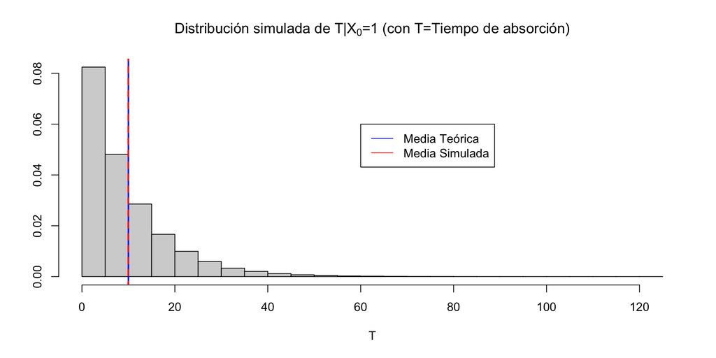

Fig. 1 Distribución simulada de $T|X_{0}=1$ y comparación media teórica y simulada

```r
hist(T.vec, probability="T",xlab="T",ylab="",main=expression(paste("Distribución simulada de T|","X"[0],"=1 (con T=Tiempo de absorción)")))
points(rep(ni1.teor,2),c(-1,1000),type="l",col="blue",lwd=2)
points(rep(ni1.sim,2),c(-1,1000),type="l",col="red",lwd=2,lty=2)
legend(60,0.06, c("Media Teórica","Media Simulada"),col=c("blue","red"),lty=c(1,1))
```

### Cálculo de la distribución de $T$ y de $E[T]$, $|E_{A}|=1$

Para ilustrar el cálculo de la distribución de $T$ y de $E[T]$ cuando el conjunto de estados absorbentes contiene un único elemento ($|E_{A}|=1$) utilizaremos de nuevo el ejercicio 8.

Generamos 100000 realizaciones del proceso utilizando la función *Trayectoria_ej8.BIS*

```r
#Trayectoria_ej8.BIS
# Genera una realizazión de longitud N+1 (siendo N el tiempo de absorción)
# de una CMHD con distribución inicial p0,  matriz de las
# probabilidades de transición de un paso P,  espacio de estados, E={1,2,...,nrow(P)}
# y k estados absorbentes (que corresponden a los últimos k estados de E)

Trayectoria_ej8.BIS=function(p0,P,k)
{
card.E=nrow(P)
k.abs=card.E-k+1  # los estados absorbentes son k.abs, k.abs+1,...,nrow(P)
E=seq(1,card.E)
X=sample(E,1,prob=p0)  #  Generamos el valor inicial X0=x0
N<-0   #  Transición actual
while (tail(X,1)<k.abs) # mientras que el sistema  no visite el conjunto de estados absorbentes...
{
    X=c(X, sample(E,1,prob=P[tail(X,1),]))
    N=N+1
}
return(list(X,N,X[N+1])) # X representa las trayectoria; N el tiempo de absorción; X[N]               # el estado en el que termina el experimento.
}
```

```r
n.sim=100000   # número de simulaciones
Trayectorias.list=list(n.sim)  # lista que contiene las n.sim trayectorias simuladas
T.vec=numeric(n.sim)   # vector que contiene los tiempos
                       # de absorción de las n.sim simulaciones
k.vec=numeric(n.sim)   # vector que contiene las n.sim celdas en las que termina
                       # el experimento
for ( i in 1:n.sim)
{
    Trayect.temp=Trayectoria_ej8.BIS(p0.ej8,P.ej8,1)
    Trayectorias.list[[i]]=Trayect.temp[[1]]
    T.vec[i]=Trayect.temp[[2]]
    k.vec[i]=Trayect.temp[[3]]
}
```

Comparación distribución teórica y simulada de $T$

```r
Distr.T.teor=function(n) # Distribución de T (ver ejercicio 8, bloque II)
{
    return( 0.8*0.1*0.9^(n-1) )
}
mean.T=8  # media de T
```

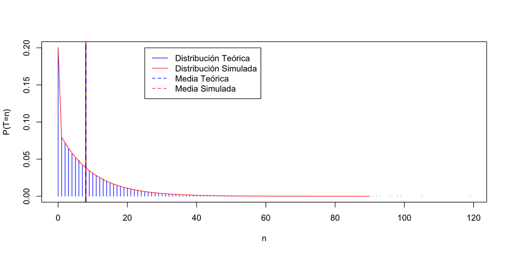

Fig. 2 Comparación distribución teórica y simulada de $T$

```r
n.values=sort(unique(T.vec))
p.simuladas=as.vector(table(T.vec)/n.sim)
plot(n.values,p.simuladas ,type="h",xlab="n",ylab="P(T=n)",col="blue")
points(seq(0,90),c(0.2,Distr.T.teor(seq(1,90))),type="l",col="red")
points(rep(mean(T.vec),2),c(-1,1000),type="l",col="red",lwd=2)
points(rep(mean.T,2),c(-1,1000),type="l",col="blue",lwd=2,lty=2)
legend(25,0.20, c("Distribución Teórica","Distribución Simulada",
"Media Teórica","Media Simulada"),col=c("blue","red","blue","red"),lty=c(1,1,2,2))
```

Repetir el cálculo de la distribución de $T$ para una cadena de Markov con las siguientes características:

```r
# E=\{0,1,2,3\}$  Espacio de estados
p0.ej8=c(0.1,0.3,0.4,0.2) # Distribución inicial
P.ej8Mod=matrix(c(0.4,0.3,0.2,0.1, # Matriz de las probabilidades de transición de un paso
             0.2,0.2,0.5,0.1,
             0.3,0.4, 0.2,0.1,
             0,0,0,1),byrow=T,ncol=4)
P.ej8Mod
```

```
##      [,1] [,2] [,3] [,4]
## [1,]  0.4  0.3  0.2  0.1
## [2,]  0.2  0.2  0.5  0.1
## [3,]  0.3  0.4  0.2  0.1
## [4,]  0.0  0.0  0.0  1.0
```

Se tiene:

```r
n.sim=100000   # número de simulaciones
Trayectorias.list.2=list(n.sim)  # lista que contiene las n.sim trayectorias simuladas
T.vec.2=numeric(n.sim)   # vector que contiene los tiempos
                       # de absorción de las n.sim simulaciones
k.vec.2=numeric(n.sim)   # vector que contiene las n.sim celdas en las que termina
                       # el experimento
for ( i in 1:n.sim)
{
    Trayect.temp.2=Trayectoria_ej8.BIS(p0.ej8,P.ej8Mod,1)
    Trayectorias.list.2[[i]]=Trayect.temp.2[[1]]
    T.vec.2[i]=Trayect.temp.2[[2]]
    k.vec.2[i]=Trayect.temp.2[[3]]
}
```

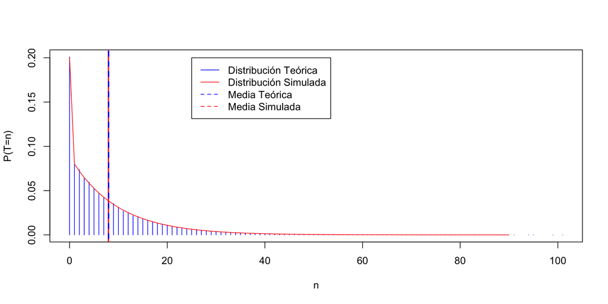

Fig. 2BIS Comparación distribución simulada de $T$ para la cadena de Markov que se ha obtenido modificando la matriz de las probabilidades de transición de un paso del ejercicio 8, con la distribución teórica de T del ejercicio 8

```r
n.values.2=sort(unique(T.vec.2))
p.simuladas.2=as.vector(table(T.vec.2)/n.sim)
plot(n.values.2,p.simuladas.2 ,type="h",xlab="n",ylab="P(T=n)",col="blue")
points(seq(0,90),c(0.2,Distr.T.teor(seq(1,90))),type="l",col="red")
points(rep(mean(T.vec.2),2),c(-1,1000),type="l",col="red",lwd=2)
points(rep(mean.T,2),c(-1,1000),type="l",col="blue",lwd=2,lty=2)
legend(25,0.20, c("Distribución Teórica","Distribución Simulada",
"Media Teórica","Media Simulada"),col=c("blue","red","blue","red"),lty=c(1,1,2,2))
```

### Cálculo $U_{ik}$

Para ilustrar el cálculo de la probabilidad de absorción en $k$ arrancando en $i$ ($U_{ik}$) utilizaremos el ejercicio 9.

```r
# E={0,1,2,3,4,5,6,7,8};
# E_{A}={7,8}
P.ej9=matrix(c(0,1/2,1/2,rep(0,6), # Matriz de las probabilidades de transición de un paso
             1/3,0,0,1/3,0,0,0,1/3,0,
             1/3,0,0,1/3,0,0,0,0,1/3,
             0,1/4,1/4,0,1/4,1/4,0,0,0,
             0,0,0,1/3,0,0,1/3,1/3,0,
             0,0,0,1/3,0,0,1/3,0,1/3,
             0,0,0,0,1/2,1/2,0,0,0,
             rep(0,7),1,0,
             rep(0,8),1),byrow=T,ncol=9)
```

Cálculo de $U_{07}$ y $U_{08}$

```r
p0.temp=c(1,rep(0,8))
n.sim=100000  # número de simulaciones
Trayectorias.list=list(n.sim)  # lista que contiene las n.sim trayectorias simuladas
T.vec=numeric(n.sim)   # vector que contiene los tiempos
                       # de absorción de las n.sim simulaciones
k.vec=numeric(n.sim)   # vector que contiene las n.sim celdas en las que termina
                       # el experimento.
for ( i in 1:n.sim)
{
    Trayect.temp=Trayectoria_ej8.BIS(p0.temp,P.ej9,2)
    Trayectorias.list[[i]]=Trayect.temp[[1]]
    T.vec[i]=Trayect.temp[[2]]
    k.vec[i]=Trayect.temp[[3]]
}
U07=as.numeric(round(table(k.vec)[1]/n.sim,2))
U08=as.numeric( round(table(k.vec)[2]/n.sim,2))
U07
```

```
## [1] 0.5
```

```r
U08
```

```
## [1] 0.5
```

Cálculo de $U_{i7}$,i=0,1,…,6

```r
n.sim=100000
Ui7.vec=numeric(7)
for ( j in 1:7)
{
p0.temp=rep(0,9)
p0.temp[j]=1
k.vec=numeric(n.sim)   # vector que contiene las n.sim celdas en las que termina
                       # el experimento
  for ( i in 1:n.sim)
   {
    Trayect.temp=Trayectoria_ej8.BIS(p0.temp,P.ej9,2)
    k.vec[i]=Trayect.temp[[3]]
    }
Ui7.vec[j]=table(k.vec)[1]/n.sim
}
round(Ui7.vec,2)
```

```
## [1] 0.50 0.67 0.33 0.50 0.67 0.34 0.50
```

### Cálculo de la distribución de T y de E[T], |E_{A}|>1 (Ejercicio 7)

Para ilustrar el cálculo de la distribución de $T$ y de $E[T]$ cuando hay más de un estado absorbente, utilizaremos el ejercicio 7.

Generamos 100000 realizaciones del proceso

```r
p0.ej7=c(3/8,2/8,2/8,1/8) # Distribucion inicial
P.ej7=matrix(c(0.3,0.2,0.1,0.4, # Matriz de las probabilidades de transición de un paso
               0.3,0.3,0.3,0.1,
               0,0,1,0,
               0,0,0,1),byrow=T,ncol=4)
P.ej7
```

```
##      [,1] [,2] [,3] [,4]
## [1,]  0.3  0.2  0.1  0.4
## [2,]  0.3  0.3  0.3  0.1
## [3,]  0.0  0.0  1.0  0.0
## [4,]  0.0  0.0  0.0  1.0
```

```r
n.sim=100000  # número de simulaciones
Trayectorias.list=list(n.sim)  # lista que contiene las n.sim trayectorias simuladas
T.vec=numeric(n.sim)   # vector que contiene los tiempos
                       # de absorción de las n.sim simulaciones
k.vec=numeric(n.sim)

for ( i in 1:n.sim)
{
    Trayect.temp=Trayectoria_ej8.BIS(p0.ej7,P.ej7,2)
    Trayectorias.list[[i]]=Trayect.temp[[1]]
    T.vec[i]=Trayect.temp[[2]]
    k.vec[i]=Trayect.temp[[3]]
}
```

Distribución simulada de T

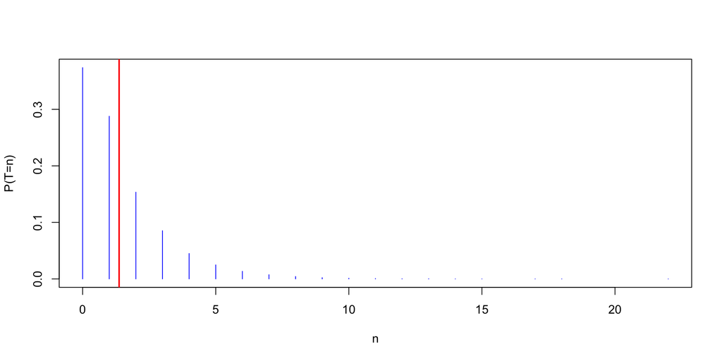

Fig. 3 Distribución simulada de $T$. La línea vertical roja representa E[T]

```r
n.values=sort(unique(T.vec))
p.simuladas=as.vector(table(T.vec)/n.sim)
plot(n.values,p.simuladas ,type="h",xlab="n",ylab="P(T=n)",col="blue")
points(rep(mean(T.vec),2),c(-1,1000),type="l",col="red",lwd=2)
```

El caso $E_{A}>1$ se puede tratar como el caso $E_{A}=1$ redefiniendo el espacio de estado (agrupando todos los estados absorbentes en un único estado absorbente). En el ejercicio 7 podríamos proceder de la siguiente manera:

```r
# E={1,2,3*}
p0.ej7BIS=c(3/8,2/8,3/8) # Distribucion inicial
P.ej7BIS=matrix(c(0.3,0.2,0.5, # Matriz de las probabilidades de transición de un paso
               0.3,0.3,0.4,
               0,0,1),byrow=T,ncol=3)
P.ej7BIS
```

```
##      [,1] [,2] [,3]
## [1,]  0.3  0.2  0.5
## [2,]  0.3  0.3  0.4
## [3,]  0.0  0.0  1.0
```

```r
n.sim=100000  # número de simulaciones
TBIS.vec=numeric(n.sim)   # vector que contiene los tiempos
                       # de absorción de las n.sim simulaciones
for ( i in 1:n.sim)
{
    Trayect.tempBIS=Trayectoria_ej8.BIS(p0.ej7BIS,P.ej7BIS,1)
    TBIS.vec[i]=Trayect.tempBIS[[2]]
}
```

Comparación distribución simulada de $T$ y $T-BIS$

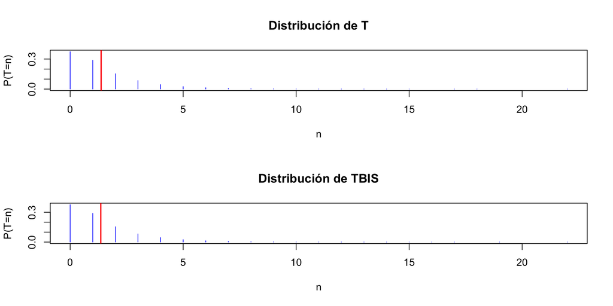

Fig. 4.1 Comparación distribución simulada de $T$ y $TBIS$. Las líneas verticales rojas representan la aproximación de E[T] obtenida por simulación

```r
n.valuesBIS=sort(unique(TBIS.vec))
p.simuladasBIS=as.vector(table(TBIS.vec)/n.sim)
par(mfrow=c(2,1))
plot(n.values,p.simuladas ,type="h",xlab="n",ylab="P(T=n)",col="blue",main="Distribución de T")
points(rep(mean(T.vec),2),c(-1,1000),type="l",col="red",lwd=2)
plot(n.valuesBIS,p.simuladasBIS ,type="h",xlab="n",ylab="P(T=n)",col="blue",main="Distribución de TBIS")
points(rep(mean(TBIS.vec),2),c(-1,1000),type="l",col="red",lwd=2)
```